# LOCKDOWN OR LOGJAM: An Analysis of the Relationship Between Waze Traffic Data and COVID-19 Transmissions in the Philippines

```python
from IPython.core.display import HTML
display(HTML("""
<script>
code_show=true;
function code_toggle() {
 if (code_show){
 $('div.input').hide();
 } else {
 $('div.input').show();
 }
 code_show = !code_show
}
$( document ).ready(code_toggle);
</script>
<form action="javascript:code_toggle()">
<input type="submit" value="Click here to toggle on/off the raw code.">
</form>"""))
```

```python
import numpy as np
import pandas as pd
import matplotlib.pyplot as plt
import matplotlib
from IPython.display import Image, display
from statsmodels.stats.multicomp import pairwise_tukeyhsd
from sklearn.model_selection import train_test_split
from sklearn.neighbors import KNeighborsRegressor
from sklearn.linear_model import LinearRegression
from sklearn.preprocessing import StandardScaler
from scipy import stats
from scipy.stats import spearmanr
from sklearn.metrics import mean_absolute_error, r2_score
from sklearn.model_selection import KFold

# display more of pandas
pd.set_option('display.max_columns', 100)
pd.set_option('display.max_rows', 100)

# silence those "setting with copy" warnings
pd.options.mode.chained_assignment = None

# prettier plots
plt.style.use('tableau-colorblind10')
# plt.style.use('seaborn-white')
plt.style.use('seaborn-talk')
matplotlib.rcParams['figure.figsize'] = (15, 10)
matplotlib.rcParams['figure.titleweight'] = 'heavy'



def bootstrap(x, y, k):
    x_train, x_test, y_train, y_test = train_test_split(x, y,
                                            test_size=0.25, random_state=42)

    sample_index = x_test.squeeze().argsort()
    x_test = x_test[sample_index]
    y_test = y_test[sample_index]

    sample_index2 = x_train.squeeze().argsort()
    x_train = x_train[sample_index2]
    y_train = y_train[sample_index2]

    n = x_train.shape[0]
    sim_size = 10000

    pred_vec = []
    score_test = []
    fig, ax = plt.subplots()
    plt.rcParams["figure.figsize"] = (12,7)
    plt.scatter(x_test, y_test)

    for i in range(sim_size):

        samp_ind = np.random.choice(range(n), size=n, replace=True)
        x_boot = x_train[samp_ind].reshape(-1, 1)
        y_boot = y_train[samp_ind]

        model = KNeighborsRegressor(n_neighbors=k).fit(x_boot, y_boot)
        pred_vec.append(model.predict(x_test))
        score_test.append(model.score(x_test, y_test))

    pi_95 = np.nanquantile(pred_vec, q=[0.025, 0.975], axis=0)

    plt.plot(x_test, model.predict(x_test), 'r--')
    ax.fill_between(x_test.flatten(), pi_95[0, :], pi_95[1, :],
                        color='tab:orange', alpha=0.2)
    plt.show()
    print('Accuracy score:', np.mean(score_test))
    return x_test.squeeze(), pi_95[0, :], pi_95[1, :], np.mean(score_test)


def plot_fb_waze(var):
    covid = pd.read_csv('pasig_cases_202001_202108.csv.gz',
                        index_col='date')
    covid.index = pd.to_datetime(covid.index)

    # Weeks start on Thursdays
    covid.index = (covid.index.year-2020)*100 + covid.index.isocalendar().week + (covid.index.weekday > 3).astype(int)
    covid = covid.dropna()
    covid = covid.groupby(by=covid.index).mean()
    df_covid = covid.merge(df3,
                   right_index=True,
                   left_index=True,
                   how = 'inner').dropna()
    plt.rcParams["figure.figsize"] = (12,7)
    logy = np.log(df_covid.num_jams)
    plt.scatter(df_covid[var], logy)
    model = LinearRegression().fit(df_covid[var].to_numpy().reshape(-1, 1),
                                   logy)
    y_hat = model.predict(df_covid[var].to_numpy().reshape(-1, 1))
    score = model.score(df_covid[var].to_numpy().reshape(-1, 1),
                        logy)
    plt.plot(df_covid[var].to_numpy().reshape(-1, 1), y_hat, color='r')
    plt.xlabel(f'Facebook: {var}')
    plt.ylabel('Waze: log of number of jams')
    print('Accuracy score:', score)

def df_covid_waze():
    covid = pd.read_csv('pasig_cases_202001_202108.csv.gz',
                        index_col='date')
    covid.index = pd.to_datetime(covid.index)

    # Weeks start on Thursdays
    covid.index = (covid.index.year-2020)*100 + covid.index.isocalendar().week + (covid.index.weekday > 3).astype(int)
    covid = covid.dropna()
    covid = covid.groupby(by=covid.index).mean()
    df_covid = covid.merge(df3,
                   right_index=True,
                   left_index=True,
                   how = 'inner').dropna()
    return df_covid

def df_covid_fb():
    covid = pd.read_csv('pasig_cases_202001_202108.csv.gz',
                        index_col='date')
    covid.index = pd.to_datetime(covid.index)

    # Weeks start on Thursdays
    covid.index = (covid.index.year-2020)*100 + covid.index.isocalendar().week + (covid.index.weekday > 3).astype(int)
    covid = covid.dropna()
    covid = covid.groupby(by=covid.index).mean()
    return covid


def score_lags(df_covid, var, k):
    for delay in range(0,5):
        x = df_covid[var].shift(delay).to_numpy()[delay:]
        y = df_covid['change'].to_numpy()[delay:]

        x_train, x_test, y_train, y_test = train_test_split(x, y,
                                                test_size=0.33, random_state=42)

        sample_index = x_test.squeeze().argsort()
        x_test = x_test[sample_index]
        y_test = y_test[sample_index]

        n = x_train.shape[0]
        sim_size = 1000

        pred_vec = []
        score_test = []
        for i in range(sim_size):

            samp_ind = np.random.choice(range(n), size=n, replace=True)
            x_boot = x_train[samp_ind].reshape(-1, 1)
            y_boot = y_train[samp_ind]

            model = KNeighborsRegressor(n_neighbors=k).fit(x_boot, y_boot)
            pred_vec.append(model.predict(x_test.reshape(-1,1)))
            score_test.append(model.score(x_test.reshape(-1,1), y_test))

        print(f"Weeks delay on {var}:", delay,
              ", Mean accuracy score:", np.mean(score_test))


def kfold_metric_check(X, y, metric, k):
    metrics = {
        'r2_score' : r2_score,
        'mean_absolute_error' : mean_absolute_error
    }
    kf = KFold(n_splits=4, random_state=42, shuffle=True)
    k_grid = range(1, k)

    mae_test_knn_all = []
    for k in k_grid:
        mae_train_knn = []
        mae_test_knn = []

        for train_index, test_index in kf.split(X):
            x_train, x_test = X[train_index], X[test_index]
            y_train, y_test = y[train_index], y[test_index]

            scaler = StandardScaler()
            x_train = scaler.fit_transform(x_train)
            x_test = scaler.transform(x_test)

            model = KNeighborsRegressor(n_neighbors=k).fit(x_train, y_train)
            fitted = model.predict(x_train)
            y_hat = model.predict(x_test)
            mae_train_knn.append(metrics[metric](y_train, fitted))
            mae_test_knn.append(metrics[metric](y_test, y_hat))

        mae_train_knn = np.array(mae_train_knn)
        mae_test_knn = np.array(mae_test_knn)

#         print('k =', k, f'Avg. Test {metric} =', mae_test_knn.mean())
        mae_test_knn_all.append(mae_test_knn)


    print(f'minimum {metric}: k =',
          np.argmin(np.mean(mae_test_knn_all, axis=1))+1,
          'MAE =', np.min(np.mean(mae_test_knn_all, axis=1)))

    fig, ax = plt.subplots()
    plt.plot(k_grid, np.mean(mae_test_knn_all, axis=1), marker='o')
    plt.title(f'Mean Absolute Error Plot - KNN Model')
```

# A. Introduction

The Philippines is still in one of the world’s strictest lockdowns. The rationale behind this policy is to reduce human movement, which should decrease virus transmission. Despite the economic consequences, we have seen how effective it is in clearing our streets of various vehicles. However, does this necessarily mean the reduction of human mobility and, in turn, new infections?

In this project, we investigate the significance of our quarantine policies to traffic congestion and virus transmission. First, we employ data from the Waze Connected Citizens Program and see the effects of the various quarantine levels. We first try to answer the question whether the quarantine was effective in reducing mobility. Next, we investigate further if the decline in vehicle volumes plowing the streets help reduce the number of new COVID-19 cases.

# B. Objective/Business Value

This study aims to use Pasig City, one of the larger cities in NCR, as a representative to analyze the relationship between traffic and the current Covid-19 pandemic. It focuses specifically on various relationships, including the following: traffic volumes in the City before and during the pandemic, traffic volumes vis-a-vis the level of quarantine measures, and lastly, traffic volumes versus the number of Covid-19 cases in the City.

Taking a closer look at one of the busiest cities in Pasig City will help play a role in providing the government a more microscopic view in implementing effective traffic policy measures during the pandemic. It will also help businesses react better to quarantine measures and inform the public better on the effectiveness of quarantine measures on the cases via the traffic situation.

**Government**: The government must balance mobility to enhance economic activity and lockdowns that reduce transmission. The study aims to hopefully provide some insights on the trade-offs on the various level of quarantine measures. As a result, some adjustments to the policies could improve the efficiency of each action.

**Businesses** : In terms of lockdowns, each level of community quarantine has a different set of guidelines and restrictions and implications on affected businesses' operations. Mobility in the form of traffic is usually a sign of economic activity. Hence, monitoring the level of traffic can be beneficial to some businesses that rely on foot traffic. They would also be able to optimize their resources and plan better for the duration of a certain level of quarantine.

**General Public** : The general public must be informed of the effects of mobility in the form of vehicular traffic to the number of cases. Through this study, the public would be aided in planning their traffic routes better as a response to the various levels of quarantine measures implemented by the government. Additionally, the results of the study can be used as an informative measure and a surface-level litmus test on the effect of quarantine to the number of Covid-19 cases.

# C. Data Description

For the traffic data, the team requested historical Waze jams data from Thinking Machines Data Science (TM). As a Waze Connected Citizens Partner, TM has been collecting traffic data on the entire country since 2018. We then generated various DataFrames for our analysis and comparison.

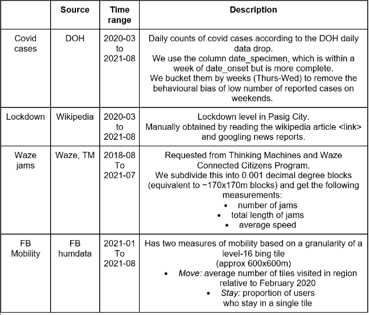

```python
Image('Data Desc.PNG')
```

### Traffic (per block-level)

```python
blocks = pd.read_hdf('/mnt/processed/private/msds2022/lt12/'
                     'DMW Final Project/data/waze.hdf5','blocks')
display(blocks.head(2), blocks.shape)
```

|  | coords | lat | lon | code |
| --- | --- | --- | --- | --- |
| 583 | (121.053, 14.577) | 14.577 | 121.053 | AA45 |
| 178 | (121.054, 14.569) | 14.569 | 121.054 | AB53 |

```
(681, 4)
```

### Traffic (city-level)

```python
pasig = pd.read_csv('pasig_level_features.csv.gz')
display(pasig.head(2), pasig.shape)
```

|  | startTime | num_jams | total_length | total_delay | ave_delay | ave_speed | ave_speed_v2 |
| --- | --- | --- | --- | --- | --- | --- | --- |
| 0 | 2018-09-28 08 | 66 | 45284 | 16087 | 0.459261 | 8.135606 | 5.735034 |
| 1 | 2018-09-28 09 | 2308 | 1560109 | 521969 | 0.410653 | 8.514545 | 6.250705 |

```
(24663, 7)
```

### Covid cases (city-level)

```python
covid = pd.read_csv('pasig_cases_202001_202108.csv.gz')
display(covid.head(2), covid.shape)
```

|  | date | cases | move | stay |
| --- | --- | --- | --- | --- |
| 0 | 2020-03-08 | 2 | NaN | NaN |
| 1 | 2020-03-09 | 15 | NaN | NaN |

```
(535, 4)
```

### Quarantine Levels

```python
date = lambda x: pd.to_datetime(x)
quarantine = pd.read_csv('quarantine.csv', index_col='date')
display(quarantine.head(2), quarantine.shape)
```

| date | quarantine |
| --- | --- |
| 2020-03-14 | CQ |
| 2020-03-15 | CQ |

```
(536, 1)
```

# 1. Is there a significant difference between the number of jams before and during the pandemic in Pasig?

Eyeballing traffic volumes after more than a year into the lockdown, it would appear to have picked up during this period. At this point, we would like to explore whether the supposed recent increase in volumes is conclusive. We use Pasig City as our sample of the overall traffic state in Metro Manila, as it is a relatively large urban area. We then aim to determine if significant mobility differences exist between the pre-pandemic and the current state.

March 14, 2020 (declaration of community quarantine) was used as the cutoff point in splitting the data: The first split contains 533 days or data points before the declaration, while the second half consists of 506 days or data points after the declaration. In order to determine if there is a significant difference before and after this date in terms of the mean number of jams in the blocks, a paired t-test on each city block was determined as the appropriate hypothesis test. Log-scaling was applied to the dataset as well.

Using Pasig City as a relatively large urban area to represent a sample of the overall state of traffic in Metro Manila, we aim to answer the question: Is there a significant difference based on the mean number of jams experienced before and after the declaration of community quarantine?

### Number of jams

- We first load the number of james per traffic block.

```python
df1 = pd.read_csv('df1.csv')
df1.head(2)
```

|  | date | pasig | (121.053, 14.577) | (121.054, 14.569) | (121.055, 14.575) | (121.055, 14.573) | (121.055, 14.57) | (121.056, 14.571) | (121.056, 14.567) | (121.057, 14.572) | (121.057, 14.568) | (121.058, 14.575) | (121.058, 14.574) | (121.058, 14.573) | (121.058, 14.568) | (121.058, 14.566) | (121.059, 14.58) | (121.059, 14.579) | (121.059, 14.578) | (121.059, 14.577) | (121.059, 14.576) | (121.059, 14.575) | (121.059, 14.574) | (121.059, 14.571) | (121.059, 14.567) | (121.06, 14.59) | (121.06, 14.587) | (121.06, 14.586) | (121.06, 14.585) | … |
| --- | --- | --- | --- | --- | --- | --- | --- | --- | --- | --- | --- | --- | --- | --- | --- | --- | --- | --- | --- | --- | --- | --- | --- | --- | --- | --- | --- | --- | --- | --- |
| 0 | 20180928 | 14295.0 | NaN | NaN | NaN | NaN | NaN | 70.0 | NaN | 21.0 | NaN | 525.0 | 224.0 | NaN | 21.0 | 84.0 | 819.0 | 77.0 | NaN | 301.0 | 525.0 | 126.0 | 168.0 | NaN | NaN | NaN | 301.0 | NaN | 525.0 | … |
| 1 | 20180929 | 29298.0 | NaN | 7.0 | NaN | NaN | NaN | 14.0 | 42.0 | 14.0 | 42.0 | 56.0 | 28.0 | 7.0 | 154.0 | 56.0 | 1078.0 | 21.0 | NaN | 252.0 | 434.0 | 70.0 | 84.0 | NaN | 42.0 | NaN | 315.0 | 7.0 | 301.0 | … |

2 rows × 683 columns

### Here some preliminary charts to visualize the difference in the two periods.

#### A. We plot the traffic levels from September 2018 (pre-pandemic) until August 2021 (during the pandemic).

- As seen below traffic levels have severely dropped during the start of 2020. However, the end of 2020 and after May 2021, traffic levels have seemed to pick up.

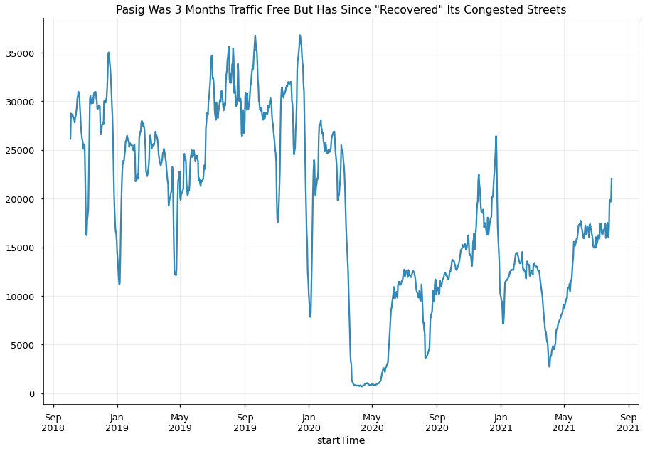

```python
df = pasig.copy()
df['startTime'] = date(df.startTime).dt.date
df = df.groupby('startTime')[['num_jams', 'total_length', 'total_delay']].sum()
df.num_jams.rolling(window=7).mean().plot(alpha=0.8)
plt.gca().xaxis.set_major_formatter(matplotlib.dates.DateFormatter('%b\n%Y'))
plt.grid(alpha=0.2)
plt.title('Pasig Was 3 Months Traffic Free But Has Since "Recovered" Its Congested Streets')
plt.show()
```

#### B. Comparison of number of days pre-pandemic and during pandemic

- We then compare our datasets in terms of dates.

```python
print('Days prior to the pandemic:', df1[df1.date < 20200314].shape[0],
      '\nDays since the start of the pandemic:', df1[df1.date >= 20200314].shape[0])
```

```
Days prior to the pandemic: 533
Days since the start of the pandemic: 506
```

- Since this is a paired t-test, we calculated the difference of the log of the means before and after the announcement of lockdown.

```python
test1 = np.log(df1.drop(['date', 'pasig'], axis=1))
test1 = test1.groupby(df1.date < 20200314, as_index=False).mean()
test1 = test1.T.dropna().rename(columns={0:'pre', 1:'post'})
test1['diff'] = test1['pre'] - test1['post']
test1_ = test1.copy()
display(test1.head())
```

|  | pre | post | diff |
| --- | --- | --- | --- |
| (121.054, 14.569) | 3.598780 | 3.077162 | 0.521617 |
| (121.055, 14.573) | 3.904077 | 3.026306 | 0.877772 |
| (121.055, 14.57) | 2.915912 | 2.747792 | 0.168120 |
| (121.056, 14.571) | 3.665724 | 3.960733 | -0.295008 |
| (121.056, 14.567) | 2.850811 | 3.733765 | -0.882954 |

#### C. We plot the differences of mean number of jams.

- Plotting the differences of mean number of jams helps visualize the distribution of the data, following a bell-shaped curve.

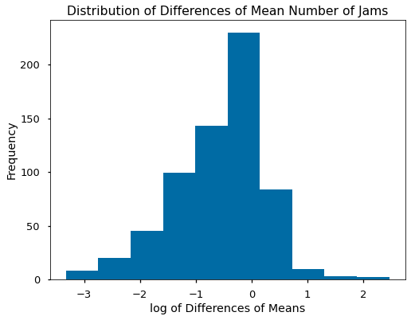

```python
plt.rcParams['figure.figsize'] = (8, 6)
plt.hist(x=test1['diff'])
plt.title('Distribution of Differences of Mean Number of Jams')
plt.xlabel('log of Differences of Means')
plt.ylabel('Frequency')
plt.show()
```

#### D. Additionally we show a box plot for the difference in mean number of jams.

- The box plot helps determine outliers in the data

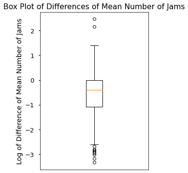

```python
plt.rcParams['figure.figsize'] = (4, 6)
plt.boxplot(test1['diff'])
plt.title('Box Plot of Differences of Mean Number of Jams')
plt.ylabel('Log of Difference of Mean Number of Jams')
plt.tick_params(axis='x', bottom=False, labelbottom=False)
plt.show()
```

## 1.A Hypothesis Testing to Compare Traffic Volumes Pre and During the Pandemic

### 1. We first define our hypothesis.

$H_0: \mu_D = 0$

$H_a: \mu_D \neq 0$

1. For our null hypothesis, there is no significant difference in the number of jams before and after the declaration of community quarantine.
1. If we reject the null hypothesis, there is a significant difference in the number of jams before and after the declaration of community quarantine.

```python
test1 = np.log(df1.drop(['date', 'pasig'], axis=1))
test1 = test1.groupby(df1.date < 20200314, as_index=False).mean()
test1 = test1.T.dropna().rename(columns={0:'pre', 1:'post'})
test1.head()
```

|  | pre | post |
| --- | --- | --- |
| (121.054, 14.569) | 3.598780 | 3.077162 |
| (121.055, 14.573) | 3.904077 | 3.026306 |
| (121.055, 14.57) | 2.915912 | 2.747792 |
| (121.056, 14.571) | 3.665724 | 3.960733 |
| (121.056, 14.567) | 2.850811 | 3.733765 |

### 2. For this test, we will set a significance level of α or alpha to 0.01.

### 3. Calculating the t-statistic and p-value. To properly conduct a paired t-test, we first need to follow assumptions provided below:

1. Scale of measurement applied to the data collected follows a *continuous* or ordinal scale.
1. The data is collected from a representative, *randomly selected* portion of the total population.
1. The data, when plotted, results in a *normal distribution*, bell-shaped distribution curve. When a normal distribution is assumed, one can specify a level of probability (alpha level, level of significance, p) as a criterion for acceptance. In most cases, a 5% value can be assumed.
1. The fourth assumption is a reasonably *large sample size* is used. A larger sample size means the distribution of results should approach a normal bell-shaped curve.
1. The final assumption is *homogeneity of variance*. Homogeneous, or equal, variance exists when the standard deviations of samples are approximately equal.

From the Central Limit Theorem, the sample mean will tend to a continuous distribution as the sample size increases, such as in our case. This resolves the first four assumptions. [1]

### For assumptions 2 and 4, the data already satisfies both conditions as the points are were generated randomly and the sample size is generally large enough to represent the population.

### For assumption 3, we do a normality check.

- The data is mostly aligned with the red line which means that it closely follows a normal distribution.

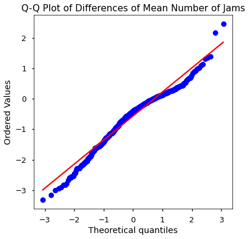

```python
# normality check
plt.rcParams['figure.figsize'] = (6, 6)
stats.probplot(test1_['diff'], dist="norm", plot=plt)
plt.title('Q-Q Plot of Differences of Mean Number of Jams')
plt.show()
```

### For assumption 5, we do a test of homogeneity.

- For the last assumption, we set a threshold of 2 for the ratio of minimum and maximum standard deviations.

```python
# homogeneity of variance check
ratio = np.log(df1.drop(['date', 'pasig'], axis=1))
ratio = ratio.groupby(df1.date < 20200314, as_index=False).std()
ratio = (ratio.max() / ratio.min()).sort_values()
idx = ratio[ratio < 2].index
test1 = test1[test1.index.isin(idx)]
display(test1)
```

|  | pre | post | diff |
| --- | --- | --- | --- |
| (121.054, 14.569) | 3.598780 | 3.077162 | 0.521617 |
| (121.055, 14.573) | 3.904077 | 3.026306 | 0.877772 |
| (121.055, 14.57) | 2.915912 | 2.747792 | 0.168120 |
| (121.056, 14.571) | 3.665724 | 3.960733 | -0.295008 |
| (121.056, 14.567) | 2.850811 | 3.733765 | -0.882954 |
| ... | ... | ... | ... |
| (121.108, 14.588) | 6.958039 | 7.284202 | -0.326163 |
| (121.109, 14.591) | 3.218849 | 3.348625 | -0.129776 |
| (121.109, 14.58) | 4.151087 | 2.807013 | 1.344074 |
| (121.11, 14.591) | 2.763146 | 3.046377 | -0.283230 |
| (121.111, 14.591) | 2.898379 | 3.314910 | -0.416531 |

613 rows × 3 columns

## 4. Determine the t-stat and the p-value.

- Now we can calculate the t-statistic and p-value which we see below:

```python
t_stat, p_value = stats.ttest_rel(test1.iloc[:, 0].values, test1.iloc[:, 1].values)
print('t_stat =', t_stat)
print('p_value =', p_value)
```

```
t_stat = -17.36927063971042
p_value = 3.082017471475158e-55
```

## 1.B Results and Discussion:

- With a p-value < 0.01, we have enough evidence to reject the null hypothesis with a significance level of 0.01. Therefore, there is a significant difference between the number of traffic jams before and after the declaration of community quarantine on March 14, 2020. The results were enough to say that the pandemic has affected the traffic levels even if there was already some form of recovery.
- Despite the increased mobility after slowly lifting lockdown restrictions, there was still a significant difference between the two periods. The mean number of jams experienced before and after the first lockdown declaration was highly divergent. As such, the pandemic was able to constrain traffic volumes despite claims of a recovery in both mobility and economic activity. However, in this case, mobility is only limited to vehicles that may not constitute the entire population.
- On the other hand, it seems to be clear that localized quarantines may contribute to reducing vehicular volumes. If policymakers are to focus on this niche, they will effectively reduce mobility in this regard. We further investigate the government’s policy of introducing different quarantine levels on the same target feature.

# 2. Is there a difference in traffic level based on the level of quarantine within Pasig City?

The previous section established that vehicle volumes were significantly affected by the pandemic due to lockdown restrictions. In this section, we try to further our analysis by looking into the effects of each quarantine restriction level.

Before lifting the first Enhanced Community Quarantine (ECQ), the government mulled over opening the economy to reduce distress for both consumers and businesses. However, mobility restrictions and health protocols should still be implemented to reduce the further spread of the virus.

In the last two years of the pandemic, the government has implemented various lockdown measures ranging from highly restrictive to generally more relaxed. As such, the government introduced four quarantine levels as follows:

1. Enhanced Community Quarantine (ECQ)
2. Modified Enhanced Community Quarantine (MECQ)
3. General Community Quarantine (GCQ)
4. Modified Community Quarantine (MGCQ)

### Defining the question:

Understanding the different levels of quarantine would potentially affect the different levels of traffic for Pasig. Hence, to confirm this, we delve further into the state of each traffic block during various lockdown measures. For this section, we will be closely looking at the significance in terms of the differences for each quarantine measure based on the traffic jams of each block.

Therefore we ask the question: Is there a significant difference in the mean number of traffic jams based on the level of quarantine within Pasig City?

### Providing a glimpse of the dataset used for analysis

```python
df2 = pd.read_csv('df1.csv', index_col='date')
df2.index = df2.index.astype(str)
quarantine.index = quarantine.index.astype(str).str.replace('-', '')
df2.insert(0, 'CQ', quarantine)
display(df2.head(2), df2.tail(2))
```

| date | CQ | pasig | (121.053, 14.577) | (121.054, 14.569) | (121.055, 14.575) | (121.055, 14.573) | (121.055, 14.57) | (121.056, 14.571) | (121.056, 14.567) | (121.057, 14.572) | (121.057, 14.568) | (121.058, 14.575) | (121.058, 14.574) | (121.058, 14.573) | (121.058, 14.568) | (121.058, 14.566) | (121.059, 14.58) | (121.059, 14.579) | (121.059, 14.578) | (121.059, 14.577) | (121.059, 14.576) | (121.059, 14.575) | (121.059, 14.574) | (121.059, 14.571) | (121.059, 14.567) | (121.06, 14.59) | (121.06, 14.587) | (121.06, 14.586) | (121.06, 14.585) | … |
| --- | --- | --- | --- | --- | --- | --- | --- | --- | --- | --- | --- | --- | --- | --- | --- | --- | --- | --- | --- | --- | --- | --- | --- | --- | --- | --- | --- | --- | --- | --- |
| 20180928 | NaN | 14295.0 | NaN | NaN | NaN | NaN | NaN | 70.0 | NaN | 21.0 | NaN | 525.0 | 224.0 | NaN | 21.0 | 84.0 | 819.0 | 77.0 | NaN | 301.0 | 525.0 | 126.0 | 168.0 | NaN | NaN | NaN | 301.0 | NaN | 525.0 | … |
| 20180929 | NaN | 29298.0 | NaN | 7.0 | NaN | NaN | NaN | 14.0 | 42.0 | 14.0 | 42.0 | 56.0 | 28.0 | 7.0 | 154.0 | 56.0 | 1078.0 | 21.0 | NaN | 252.0 | 434.0 | 70.0 | 84.0 | NaN | 42.0 | NaN | 315.0 | 7.0 | 301.0 | … |

2 rows × 683 columns

| date | CQ | pasig | (121.053, 14.577) | (121.054, 14.569) | (121.055, 14.575) | (121.055, 14.573) | (121.055, 14.57) | (121.056, 14.571) | (121.056, 14.567) | (121.057, 14.572) | (121.057, 14.568) | (121.058, 14.575) | (121.058, 14.574) | (121.058, 14.573) | (121.058, 14.568) | (121.058, 14.566) | (121.059, 14.58) | (121.059, 14.579) | (121.059, 14.578) | (121.059, 14.577) | (121.059, 14.576) | (121.059, 14.575) | (121.059, 14.574) | (121.059, 14.571) | (121.059, 14.567) | (121.06, 14.59) | (121.06, 14.587) | (121.06, 14.586) | (121.06, 14.585) | … |
| --- | --- | --- | --- | --- | --- | --- | --- | --- | --- | --- | --- | --- | --- | --- | --- | --- | --- | --- | --- | --- | --- | --- | --- | --- | --- | --- | --- | --- | --- | --- |
| 20210731 | GCQ | 22594.0 | NaN | 315.0 | NaN | 203.0 | NaN | 266.0 | 14.0 | NaN | 7.0 | 392.0 | 56.0 | NaN | 21.0 | 70.0 | 133.0 | 91.0 | 56.0 | 77.0 | 1092.0 | 56.0 | 14.0 | 35.0 | 14.0 | 14.0 | 196.0 | NaN | 7.0 | … |
| 20210801 | GCQ | NaN | NaN | 7.0 | NaN | NaN | NaN | NaN | NaN | NaN | NaN | NaN | NaN | NaN | NaN | NaN | 35.0 | NaN | NaN | 14.0 | 14.0 | 7.0 | NaN | NaN | NaN | NaN | NaN | NaN | NaN | … |

2 rows × 683 columns

```python
test2 = df2.replace({'CQ': 'ECQ', 'GCQ-MECQ':'GCQ'})
test2 = test2[['CQ', 'pasig']].dropna()
ECQ = test2[test2['CQ'] == 'ECQ'].pasig.dropna()
GCQ = test2[test2['CQ'] == 'GCQ'].pasig.dropna()
MECQ = test2[test2['CQ'] == 'MECQ'].pasig.dropna()
MGCQ = test2[test2['CQ'] == 'MGCQ'].pasig.dropna()
quar_level = ['ECQ', 'GCQ', 'MECQ', 'MGCQ']
test2_ = [ECQ, GCQ, MECQ, MGCQ]
test2_ = list(map(np.log, test2_))
```

### Some charts to visualize the descriptive statisctics for each quarantine measure.

#### We plot the number of days in the various levels of lockdown.

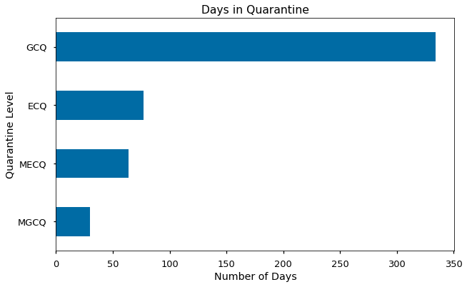

```python
plt.rcParams['figure.figsize'] = (10, 6)
test2.CQ.value_counts().sort_values().plot.barh()
plt.title('Days in Quarantine')
plt.xlabel('Number of Days')
plt.ylabel('Quarantine Level')
plt.show()
```

#### We plot the distribution of the daily number of jams.

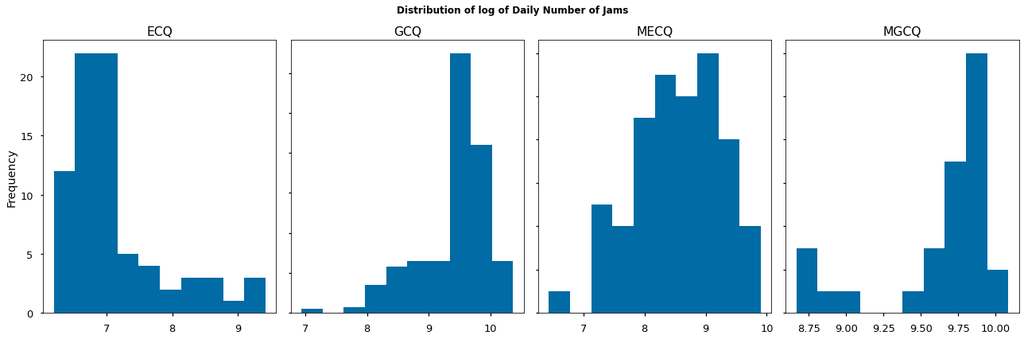

```python
plt.rcParams['figure.figsize'] = (18, 6)
fig, axs = plt.subplots(1,4)
for idx, q in enumerate(test2_):
    axs[idx].hist(x=q)
    axs[idx].set_title(quar_level[idx])
    axs[idx].set_ylabel('Frequency')
fig.suptitle('Distribution of log of Daily Number of Jams')
for ax in axs.flat:
    ax.label_outer()
plt.tight_layout()
plt.show()
```

## 2.A Hypothesis Testing to Compare the Difference in Means for Traffic Levels Based on the Different Levels of Quarantine

### 1. We first define the hypothesis.

$H_0: \mu_1 = \mu_2 = \mu_3 =\mu_4$

$H_a: \mu_1 \neq \mu_2 \neq \mu_3 \neq \mu_4$

1. For our null hypothesis, there is no significant difference in the mean number of jams between different quarantine levels in Pasig City.
2. For our alternative hypothesis, there is a significant difference in the mean number of jams between different quarantine levels in Pasig City.

### 2. We set the significance level α to 0.01.

### 3. Calculating the F-statistic and p-value. To compare the mean number of jams of the different levels of quarantine, we test the hypothesis using One-Way Analysis of Variance (ANOVA).

#### Here are the probability plots for each quarantine measure.

[figure not shown]

```python
plt.rcParams['figure.figsize'] = (15, 6)
fig, axs = plt.subplots(1, 4)
for idx, q in enumerate(test2_):
    stats.probplot(q, dist="norm", plot=axs[idx])
    axs[idx].set_title(quar_level[idx])
for ax in axs.flat:
    ax.label_outer()
plt.tight_layout()
plt.show()
```

### One-way Test via F-Statistics

With p-value < 0.01, we have enough evidence to reject the null hypothesis up with a significance level of 0.01. Therefore, there is a significant difference between at least one of the mean number of jams between different quarantine levels in Pasig City.

```python
F, p = stats.f_oneway(ECQ, GCQ, MECQ, MGCQ)
print('F-statistic =', F, '\np-value =', p)
```

```
F-statistic = 135.03165909062616
p-value = 4.1313920109532693e-64
```

#### 6. Implementing the Post Hoc Test. Using Pairwise Tukey to Compare the Means.

After using One-Way ANOVA, it is possible to determine which quarantine levels are actually significantly different using the Tukey Test or Honest Significant Difference. This employs pairwise testing to see which are different from each other. Again, we employ a significance level alpha = 0.01. The results of this test are given below.

```python
m_comp = pairwise_tukeyhsd(endog=test2['pasig'],
                           groups=test2['CQ'], alpha=0.01)
print(m_comp)
```

```
    Multiple Comparison of Means - Tukey HSD, FWER=0.01
============================================================
group1 group2  meandiff  p-adj    lower      upper    reject
------------------------------------------------------------
   ECQ    GCQ 11951.5608  0.001  9861.9985 14041.1231   True
   ECQ   MECQ  4591.4117  0.001  1795.4758  7387.3476   True
   ECQ   MGCQ 14713.0294  0.001 11155.5786 18270.4803   True
   GCQ   MECQ  -7360.149  0.001 -9615.5893 -5104.7088   True
   GCQ   MGCQ  2761.4687 0.0319  -388.9614  5911.8987  False
  MECQ   MGCQ 10121.6177  0.001  6464.2694  13778.966   True
------------------------------------------------------------
```

## 2.B Results and Discussion:

The Pairwise Test indicates that we can reject the null hypotheses for all pairs except for the GCQ and MGCQ, and say that there are significant differences in the various level of lockdown measures.

- In terms of policy, most quarantine measures seem to be effective in reducing mobility even at different levels of implementation. However, for GCQ and MGCQ, the guidelines and restrictions may be revisited since the difference in mobility seems to be insignificant. However, we would like to emphasize that this only applies to vehicular traffic.
- Additionally, the government may revisit its guidelines and restrictions for each level of lockdown based on the effects of each one to mobility. Mobility is one of the key indicators of economic activity.
- For businesses, if there are generally clear cut levels in terms of increased traffic levels, and therefore, higher foot traffic across the different quarantine measures. However, since GCQ and MGCQ do not seem far off in terms of mobility, businesses could hesitate opening up and scaling their operation.
- Increasing the reliability of quarantine measures could also increase consumer sentiment. Generally, business would be more receptive to the policy measures since transitioning between each type of quarantine will be smoother, and their projections will be more robust and accurate.

# 3. Does the level of mobility derived from the traffic volumes affect the number of cases?

We have so far discussed vehicular traffic and volumes during the pandemic. However, we have not asked the most important question, would this matter to reduce the transmission and spread of the virus?

In this section, we again look into traffic jams and scrutinize its effect on the number of COVID cases. In order to be sure of our findings, we introduce another mobility data from Facebook. We first compared both mobility metrics to see any correlation, and we eventually used bootstrapping to arrive at a prediction interval for change in COVID cases based on the number of jams using KNN Regression. Using both mobility metrics, we hope to find some relevance with current quarantine policy as an effective health response.

### We first filter our Covid-19 Data.

```python
covid = pd.read_csv('pasig_cases_202001_202108.csv.gz', index_col='date')
display(covid.head(2))

covid.index = pd.to_datetime(covid.index)

# Weeks start on Thursdays
covid.index = (covid.index.year-2020)*100 +\
covid.index.isocalendar().week + (covid.index.weekday > 3).astype(int)
covid = covid.groupby(by=covid.index).cases.sum().to_frame()
# Note that the data starts on a Monday so the first item
#represents only 4 days instead of 7
covid.loc[5, 'cases'] = np.nan
covid['change'] = (covid['cases']-
                   covid['cases'].shift(1))/covid['cases'].shift(1)

df = pasig
df['startTime'] = date(df.startTime)
df['week'] = (df.startTime.dt.year-2020)*100 +\
df.startTime.dt.isocalendar().week + (df.startTime.dt.weekday > 3).astype(int)
df = df.groupby('week')[['num_jams', 'total_length', 'total_delay']].sum()
```

| date | cases | move | stay |
| --- | --- | --- | --- |
| 2020-03-08 | 2 | NaN | NaN |
| 2020-03-09 | 15 | NaN | NaN |

```python
df3 = df.join(covid, how='right')
weekly = df3.copy().sort_index()
df3['log_jams'] = np.log(df3.num_jams)
display(df3.head(), df3.tail())
```

|  | num_jams | total_length | total_delay | cases | change | log_jams |
| --- | --- | --- | --- | --- | --- | --- |
| 11 | 121755.0 | 76809673.0 | 22840472.0 | 47.0 | NaN | 11.709766 |
| 12 | 47725.0 | 27087366.0 | 10760506.0 | 28.0 | -0.404255 | 10.773211 |
| 13 | 6761.0 | 2275060.0 | 941203.0 | 46.0 | 0.642857 | 8.818926 |
| 14 | 5621.0 | 1828902.0 | 788201.0 | 42.0 | -0.086957 | 8.634265 |
| 15 | 5567.0 | 1854467.0 | 773328.0 | 61.0 | 0.452381 | 8.624612 |

|  | num_jams | total_length | total_delay | cases | change | log_jams |
| --- | --- | --- | --- | --- | --- | --- |
| 133 | NaN | NaN | NaN | 1811.0 | 0.360631 | NaN |
| 134 | NaN | NaN | NaN | 2214.0 | 0.222529 | NaN |
| 135 | NaN | NaN | NaN | 432.0 | -0.804878 | NaN |
| 154 | 7045.0 | 4083576.0 | 873388.0 | 29.0 | -0.932870 | 8.860073 |
| 5 | 179728.0 | 113834526.0 | 39374679.0 | NaN | NaN | 12.099200 |

## 3.A Exploratory Data Analysis

### 3.A.1 Facebook data vs. Waze data

For this EDA, we used linear regression to determine how the number of jams based on Waze data positively and negatively correlates to Facebook's mobility data on `move` and `stay`, respectively. This strengthens our assumption in using `num_jams` from Waze to represent mobility.

```
Accuracy score: 0.5409454431610656
```

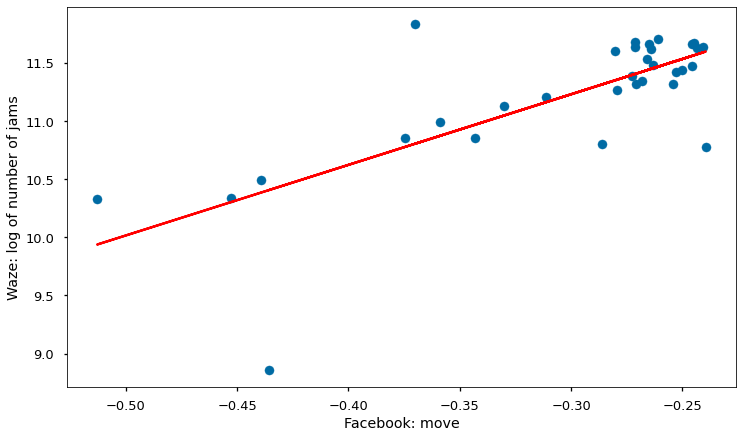

```python
plot_fb_waze('move')
```

```
Accuracy score: 0.4102864641383023
```

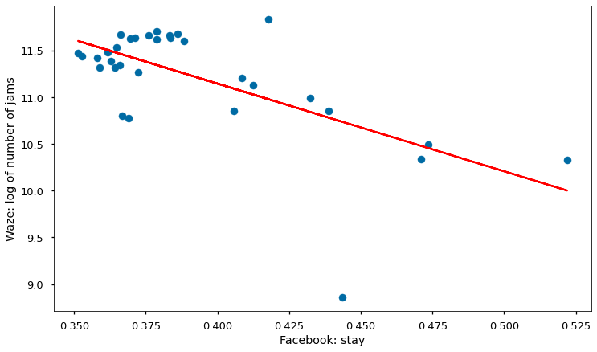

```python
plot_fb_waze('stay')
```

## 3.A.2 Change in COVID cases vs `num_jams` in delay

We use `num_jams` as our mobility measure. We determine if there exists a relationship between level of mobility and change in COVID cases based on plots below. Change is represented by week-on-week percentage change, while `num_jams` is shifted from 0 to 4 weeks back to evaluate how current cases react to previous mobility patterns.

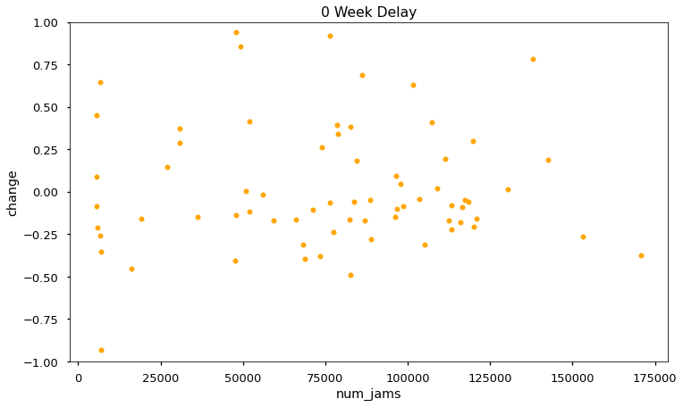

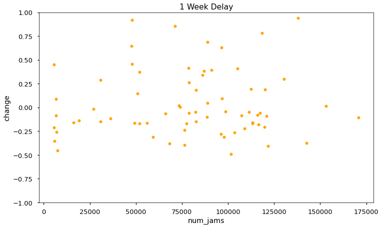

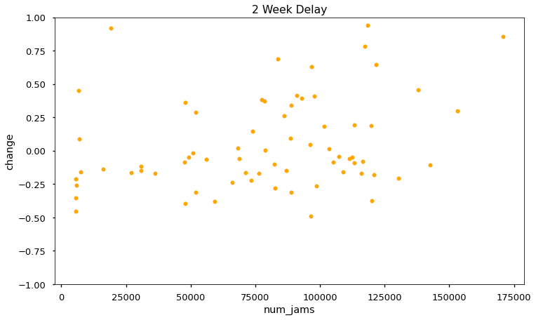

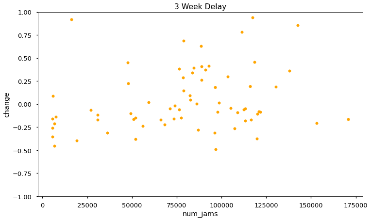

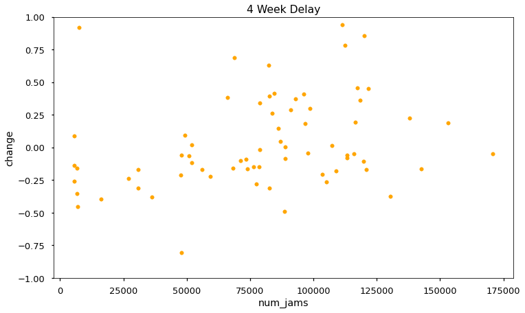

```python
x1 = 'num_jams'
x2 = 'total_delay'
for lag in range(5):
    plt.title(f'{lag} Week Delay')
    plt.scatter(df3[x1].shift(lag), df3['change'],
                marker='o', c='orange', s=30)
    plt.xlabel(x1)
    plt.ylabel('change')
    plt.ylim(-1, 1)
    plt.show()
```

## 3.B Performing Bootstrap on `num_jams`: 2 week delay

### 3.B.1 Mean accuracy score across num_jams in delay

To extend the EDA performed above, we fit a KNN-regression model on `num_jams` in delay and `change`. We printed the mean accuracy score below. As expected, since COVID cases have a 14-day incubation period, we observe the best accuracy score when delay is at 2 weeks. This suggests that mobility's impact on change in COVID cases is best seen in lag of 2 weeks. Thus, we will focus our analysis on `num_jams` with a 2-week delay.

```python
score_lags(df3.dropna(), 'num_jams', 14)
```

```
Weeks delay on num_jams: 0 , Mean accuracy score: -0.4819836631971384
Weeks delay on num_jams: 1 , Mean accuracy score: -0.31412274374236565
Weeks delay on num_jams: 2 , Mean accuracy score: -0.017674306986925355
Weeks delay on num_jams: 3 , Mean accuracy score: -0.19142599685941872
Weeks delay on num_jams: 4 , Mean accuracy score: -0.13768511327201222
```

### 3.B.2 Perform Cross-Validation and Bootstrapping

```python
df_bootstrap = df3.copy()
df_bootstrap['num_jams_2wk_delay'] = df_bootstrap['num_jams'].shift(2)
df_bootstrap = df_bootstrap[['num_jams_2wk_delay', 'change']].dropna()
x = df_bootstrap['num_jams_2wk_delay'].to_numpy().reshape(-1,1)
y = df_bootstrap['change'].to_numpy()
```

### 3.B.2.A Perform Cross-Validation

- Since our data set has a non-linear distribution, we used a cross validation technique to verify by using another metric in choosing the best model. We checked the Mean Absolute Error for the K Nearest Neighbor model to know what is the best `number of neighbor` to use before performing bootstrap.

```
minimum mean_absolute_error: k = 20 MAE = 0.3617825864743987
```

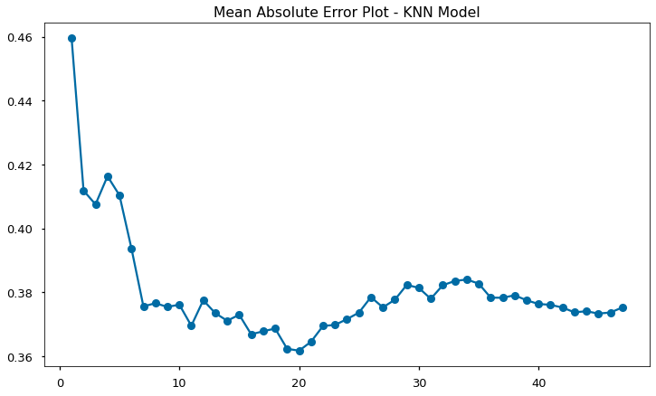

```python
kfold_metric_check(x, y, 'mean_absolute_error', 48)
```

### 3.B.2.B Perform Bootstrapping

We perform bootstraping in order to arrive at a prediction interval for change in COVID cases based on number of jams using KNN Regression. We note that the cross-validation exercise suggests 20 k-neighbors for the lowest error metric so we set our model to that parameter.

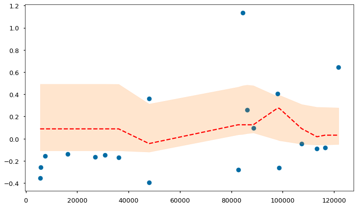

```
Accuracy score: -0.1771395612764735
```

```python
x_test_boot, pi_95_lower, pi_95_upper, mean_score = bootstrap(x, y, 20)
```

### 3.B.3 Prediction interval

We show the prediction interval obtained from the bootstrapping exercise below. We note that we have a very low accuracy score, and there are many peculiarities with our prediction. At the lowest level of mobility, the upper bound of the 95% prediction interval for change in COVID cases is very high compared to when we have a higher level of mobility. We also have an extensive range for the prediction interval. Given the low accuracy score in the bootstrapping exercise and high error metric in the cross-validation exercise, we can assume the following:

1. Either our current model is not good for prediction, or
2. There may be no relationship between number of jams and change in covid cases

```python
df_pi = pd.DataFrame(zip(x_test_boot,
                    pi_95_lower,
                    pi_95_upper),
                    columns = ['num_jams', '95_pred_int_lower',
                               '95_pred_int_upper'])
df_pi
```

|  | num_jams | 95_pred_int_lower | 95_pred_int_upper |
| --- | --- | --- | --- |
| 0 | 5567.0 | -0.107889 | 0.492655 |
| 1 | 5896.0 | -0.107889 | 0.492655 |
| 2 | 7599.0 | -0.107889 | 0.492655 |
| 3 | 16275.0 | -0.107889 | 0.492655 |
| 4 | 26921.0 | -0.107889 | 0.492655 |
| 5 | 30895.0 | -0.107889 | 0.492655 |
| 6 | 36134.0 | -0.107889 | 0.491688 |
| 7 | 47957.0 | -0.119308 | 0.314061 |
| 8 | 47986.0 | -0.119308 | 0.314061 |
| 9 | 82649.0 | 0.036501 | 0.466613 |
| 10 | 84443.0 | 0.040125 | 0.479015 |
| 11 | 86172.0 | 0.047219 | 0.484716 |
| 12 | 88558.0 | 0.053490 | 0.479085 |
| 13 | 97918.0 | -0.010307 | 0.382203 |
| 14 | 98650.0 | -0.016498 | 0.393430 |
| 15 | 107353.0 | -0.047677 | 0.310024 |
| 16 | 113302.0 | -0.056070 | 0.284971 |
| 17 | 116493.0 | -0.054693 | 0.283301 |
| 18 | 121755.0 | -0.050617 | 0.279133 |

### 3.B.4 Correlation test

Given the peculiar results above, we perform a correlation test to determine the relationship between the two variables. We use the Spearman rank correlation coefficient since there appears to be no linear relationship between the two variables. The Spearman rank correlation coefficient measures the monotonic relationship between 2 variables without assuming a linear relationship. The Spearman rank correlation coefficient's value ranges from -1 to 1. As long as Y increases as X increases, regardless of how much, the Spearman Rank Correlation Coefficient will be 1.

Based on the result of 0.21, we have a weak monotonically increasing relationship. Thus, based on `num_jams`, the effect of quarantine on change in COVID cases may be very minimal. [2]

```python
corr, _ = spearmanr(x, y)
print('Spearmans correlation: %.3f' % corr)
```

```
Spearmans correlation: 0.210
```

## 3.C. Performing Bootstrapping on Facebook's `move`: 2 week delay

Since we had peculiar results in the section above, we now try using Facebook's `move` data to represent mobility. Albeit there are fewer points, we may see better results.

### 3.C.1. Mean accuracy score across `move` in delay

Similarly, we get the best accuracy score when `move` is at 2-weeks delay. Thus, we focus our analysis for `move` at a 2-week lag.

```python
score_lags(df_covid_waze(), 'move', 10)
```

```
Weeks delay on move: 0 , Mean accuracy score: -0.777228768861966
Weeks delay on move: 1 , Mean accuracy score: -0.33303738903212204
Weeks delay on move: 2 , Mean accuracy score: 0.07036726741680127
Weeks delay on move: 3 , Mean accuracy score: 0.005614915137429713
Weeks delay on move: 4 , Mean accuracy score: -0.08365088367545104
```

### 3.C.2 Perform Bootstrapping

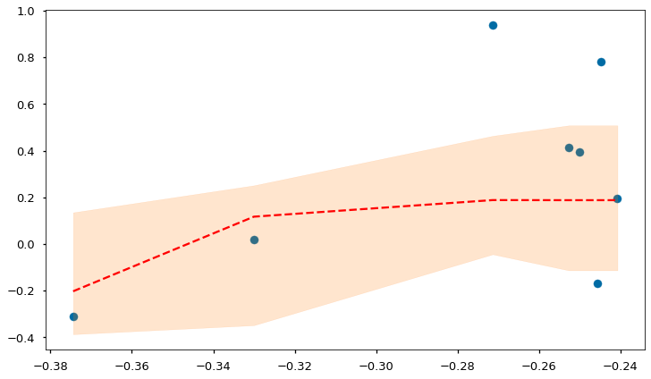

```
Accuracy score: -0.03365878909365521
```

```python
df_fb_boot = df_covid_waze()
df_fb_boot['move_2wk_delay'] = df_fb_boot['move'].shift(2)
df_fb_boot = df_fb_boot[['move_2wk_delay',
                                'change']].dropna()
x = df_fb_boot['move_2wk_delay'].to_numpy().reshape(-1,1)
y = df_fb_boot['change'].to_numpy()
x_test_boot, pi_95_lower, pi_95_upper, mean_score = bootstrap(x, y, 10)
```

## 3.C.3 Prediction interval

We show the prediction interval below. The prediction interval for lower levels of mobility leans towards a decrease in COVID cases. In comparison, the prediction interval for higher levels of mobility leans towards an increase in COVID cases. This suggests that mobility may impact cases, allowing us to predict `change` based on `move` to an extent. However, the wide range for prediction intervals suggests that restricting mobility alone does not guarantee a decrease in cases.

```python
df_pi = pd.DataFrame(zip(x_test_boot,
                    pi_95_lower,
                    pi_95_upper),
                    columns = ['move', '95_pred_int_lower',
                               '95_pred_int_upper'])
df_pi
```

|  | move | 95_pred_int_lower | 95_pred_int_upper |
| --- | --- | --- | --- |
| 0 | -0.374437 | -0.386515 | 0.135441 |
| 1 | -0.330033 | -0.347969 | 0.251274 |
| 2 | -0.271359 | -0.043852 | 0.463404 |
| 3 | -0.252709 | -0.112618 | 0.508260 |
| 4 | -0.250164 | -0.112618 | 0.508260 |
| 5 | -0.245613 | -0.112618 | 0.508260 |
| 6 | -0.244706 | -0.112618 | 0.508260 |
| 7 | -0.240727 | -0.112618 | 0.508260 |

### 3.C.4 Correlation test

We compute for the Spearman's correlation and see a stronger increasing relationship between `change` and `move` comapred to `num_jams`. However, a 0.39 correlation value is still considered a weak relationship.

```python
corr, _ = spearmanr(x, y)
print('Spearmans correlation: %.3f' % corr)
```

```
Spearmans correlation: 0.399
```

## 3.D Performing Bootstrapping on `stay`: 2 week delay

We now try using Facebook's `stay` data to represent mobility. We aim to see if there will be any difference in our analysis.

### 3.D.1. Mean accuracy score across `stay` in delay

Similarly, we get the best accuracy score when `stay` is at 2-weeks delay. Thus, we focus our analysis for `stay` at a 2-week lag.

```python
score_lags(df_covid_waze(), 'stay', 10)
```

```
Weeks delay on stay: 0 , Mean accuracy score: -0.704742820028084
Weeks delay on stay: 1 , Mean accuracy score: -0.25124062824091437
Weeks delay on stay: 2 , Mean accuracy score: 0.06671713982305259
Weeks delay on stay: 3 , Mean accuracy score: 0.04234211874213162
Weeks delay on stay: 4 , Mean accuracy score: 0.02581936905719177
```

### 3.D.2 Perform Bootstrapping

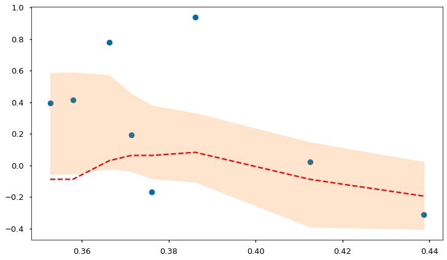

```
Accuracy score: -0.009610854792178386
```

```python
df_fb_boot2 = df_covid_waze()
df_fb_boot2['stay_2wk_delay'] = df_fb_boot2['stay'].shift(2)
df_fb_boot2 = df_fb_boot2[['stay_2wk_delay',
                                'change']].dropna()
x = df_fb_boot2['stay_2wk_delay'].to_numpy().reshape(-1,1)
y = df_fb_boot['change'].to_numpy()
x_test_boot, pi_95_lower, pi_95_upper, mean_score = bootstrap(x, y, 10)
```

### 3.D.3 Prediction interval

We show the prediction interval below. The prediction interval for lower levels of `stay` lean towards an increase in COVID cases, while the prediction interval for higher levels of `stay` lean towards a decrease in COVID cases. This suggests that citizens staying at home may impact cases, allowing us to predict `change` based on `stay` to an extent.

```python
df_pi = pd.DataFrame(zip(x_test_boot,
                    pi_95_lower,
                    pi_95_upper),
                    columns = ['stay', '95_pred_int_lower',
                               '95_pred_int_upper'])
df_pi
```

|  | stay | 95_pred_int_lower | 95_pred_int_upper |
| --- | --- | --- | --- |
| 0 | 0.352693 | -0.056793 | 0.585114 |
| 1 | 0.357940 | -0.056303 | 0.588587 |
| 2 | 0.366290 | -0.022758 | 0.572307 |
| 3 | 0.371330 | -0.037023 | 0.454977 |
| 4 | 0.376076 | -0.084276 | 0.379016 |
| 5 | 0.386119 | -0.106607 | 0.330530 |
| 6 | 0.412554 | -0.390786 | 0.146213 |
| 7 | 0.438744 | -0.405297 | 0.021785 |

### 3.D.4 Correlation test

We compute for the Spearman's correlation and see a decreasing relationship between `change` and `stay`. Across all mobility measures, `stay` appears to have the strongest relationship with `change`.

Based on this, government policies that encourage people to stay at home suggest decreasing COVID cases after two weeks. At a correlation value of -0.5, we may consider this a moderate level of relationship between the two variables. However, while there is an impact, the effect of quarantine may not be as strong as we think and is not always a guarantee for a decrease in COVID levels.

```python
corr, _ = spearmanr(x, y)
print('Spearmans correlation: %.3f' % corr)
```

```
Spearmans correlation: -0.530
```

# E. Conclusion and Recommedations

The mean number of jams experienced before and after the first lockdown declaration was highly divergent. As such, the pandemic was able to constrain traffic volumes despite claims of a recovery in both mobility and economic activity. On the other hand, it seems clear that localized quarantines may reduce vehicular volumes.

When looking into the government’s quarantine classifications, most seem to have a clear delineation between their respective implementations. However, for GCQ and MGCQ, the guidelines and restrictions may be revisited since the difference in mobility seems to be insignificant. As such, the government may have to review the guidelines and restrictions of these two classifications.

We believe there is considerable ambiguity between GCQ and MGQC, which might harm consumer and business sentiment. Since neither classification seems far off in terms of mobility, businesses could hesitate to open up and scale their operation. They would be more receptive to the policy measures since transitioning between each type of quarantine will be smoother, and their projections will be more robust and accurate.

Lastly, in terms of the effect of traffic volumes to the actual number of cases, we were able to find some correlation. However, the results could be improved further. For the traffic jams and each measure of mobility, we had a wide range for prediction interval, low accuracy scores in the bootstrap sampling, and high errors scores for our K-Fold cross-validation. The relatively weak measuring scores may indicate that other factors may significantly affect the Covid Cases. Hence, we may need to introduce additional features aside from the traffic and mobility data used to tackle the problem, such as vaccination levels, train ridership and other public transportation metrics, and foot traffic in various points of interest such as malls. Additionally, this study can be improved further by applying more complex models to fit the data. Despite this, and given the results, we were able to generate some insights and recommendations:

- Lower mobility, to some degree, has an impact on the decrease in Covid-19 Cases. Hence, we can roughly suggest that there is merit in limiting mobility. However, the low magnitude and minimal impact of traffic mobility on cases underscore the importance of looking at other more effective prevention methods such as vaccination.
- Government policies and advocacies that encourage home-based activities to a certain extent help in decreasing the cases. But given the relatively low impact of mobility, we also recommend exploring more significant measures such as emphasizing social distancing.
- Lastly, people choosing to stay at home has an impact on the cases. Therefore, individuals should continue to think twice before going to public places, especially if there is no reason.

# References:

1. https://www.statisticshowto.com/tukey-test-honest-significant-difference/
2. https://stackabuse.com/calculating-spearmans-rank-correlation-coefficient-in-python-with-pandas/
3. Protecting privacy in Facebook mobility data during the COVID-19 response - Facebook Research (fb.com)
4. DeGroot, M. H., & Schervish, M. J. (2012). Probability and Statistics (4th Edition).

Data sources:

1. https://data.gov.ph/?q=dataset/covid-19-doh-data-drop-august-30-2021
2. https://data.humdata.org/dataset/movement-range-maps#
3. https://en.wikipedia.org/wiki/COVID-19_community_quarantines_in_the_Philippines
4. https://en.wikipedia.org/wiki/Enhanced_community_quarantine_in_Luzon